# Demo: Grouping and Aggregating

### 1. Import Packages and Connect to the CAS Server

Visit the documentation for the SWAT [(SAS Scripting Wrapper for Analytics Transfer)](https://sassoftware.github.io/python-swat/index.html) package.

```python
## Import packages
import swat
import pandas as pd
import matplotlib.pyplot as plt
plt.style.use('seaborn')

## Set options
pd.set_option('display.max_columns', None)

## Connect to CAS
conn = swat.CAS('server.demo.sas.com', 30571, 'student', 'Metadata0', name = 'py03d05')

## Function to load the loans_raw.sashdat file into memory if necessary
def loadLoans():
    conn.loadTable(path = 'loans_raw.sashdat', caslib = 'PIVY',
                   casOut = {'name' : 'loans_raw',
                            'caslib' : 'casuser',
                            'promote' : True})
```

### 2. Explore Available CAS Tables and Data Source Files

a. Use the tableInfo action to view all available in-memory tables in the **Casuser** caslib. If the **LOANS_RAW** CAS table is not available, uncomment the loadLoans function and execute the cell.

```python
#loadLoans()
conn.tableInfo(caslib = 'casuser')
```

**§ TableInfo**

|  | Name | Label | Rows | Columns | IndexedColumns | Encoding | CreateTimeFormatted | ModTimeFormatted | AccessTimeFormatted | JavaCharSet | CreateTime | ModTime | AccessTime | Global | Repeated | View | MultiPart | SourceName | SourceCaslib | Compressed | Creator | Modifier | SourceModTimeFormatted | SourceModTime |
| --- | --- | --- | --- | --- | --- | --- | --- | --- | --- | --- | --- | --- | --- | --- | --- | --- | --- | --- | --- | --- | --- | --- | --- | --- |
| 0 | CARS | 2004 Car Data | 428 | 15 | 0 | utf-8 | 2022-03-17T19:30:27+00:00 | 2022-03-17T19:30:27+00:00 | 2022-03-17T20:27:32+00:00 | UTF8 | 1.963165e+09 | 1.963165e+09 | 1.963168e+09 | 1 | 0 | 0 | 0 | cars.sas7bdat | PIVY | 0 | student |  | 2021-12-17T18:43:57+00:00 | 1.955386e+09 |
| 1 | LOANS_RAW |  | 16311047 | 20 | 0 | utf-8 | 2022-03-17T20:28:57+00:00 | 2022-03-17T20:28:57+00:00 | 2022-03-17T20:34:08+00:00 | UTF8 | 1.963168e+09 | 1.963168e+09 | 1.963168e+09 | 1 | 0 | 0 | 0 | loans_raw.sashdat | PIVY | 0 | student |  | 2021-12-17T18:40:14+00:00 | 1.955386e+09 |

elapsed 0.00318s · user 0.000581s · sys 0.00184s · mem 0.826MB

b. Reference the **LOANS_RAW** CAS table using the CASTable method. Within the CASTable method, add the where parameter to filter for rows where **Category** equals *Credit Card*. This is an alternate method to add the where parameter to a **CASTable** object. Then preview the CAS table using the head method.

```python
## All rows where Category equals Credit Card
ccTbl = conn.CASTable('loans_raw',
                      caslib = 'casuser',
                      where = 'Category = "Credit Card"')
display(ccTbl)

## Preview the table
ccTbl.head()
```

```
CASTable('loans_raw', caslib='casuser', where='Category = "Credit Card"')
```

Selected Rows from Table LOANS_RAW

|  | ID | AccNumber | Year | Month | Day | CurrentDate | SalaryGroup | Age | Salary | EmpLength | Category | Amount | InterestRate | LoanLength | LoanGrade | LoanStatus | LastPurchase | Cancelled | CancelledReason | Promotion |
| --- | --- | --- | --- | --- | --- | --- | --- | --- | --- | --- | --- | --- | --- | --- | --- | --- | --- | --- | --- | --- |
| 0 | I-00006307127350009978 | PKEO-1058-5781-4683-1737 | 2020.0 | 7.0 | 16.0 | 31DEC2022 | Less than $50,000 | 30.0 | 9128.0 | 11.0 | Credit Card | 2883.72 | 16.78 | 999999.0 | C | Late | 2022-12-16 | 0.0 |  | 0.0 |
| 1 | G-00005046456530690193 | PKEO-0775-3531-9166-5132 | 2020.0 | 2.0 | 10.0 | 31DEC2022 | $50,001 - $100,000 | 46.0 | 92000.0 | 10.0 | Credit Card | 10957.10 | 13.62 | 999999.0 | B | Current | 2022-03-19 | 0.0 |  | 0.0 |
| 2 | C-00006496445944067091 | PKEO-0832-4079-2767-3394 | 2013.0 | 5.0 | 5.0 | 31DEC2022 | Less than $50,000 | 28.0 | 17029.0 | 14.0 | Credit Card | 5257.41 | 21.83 | 999999.0 | B | Current | 2014-08-07 | 0.0 |  | 0.0 |
| 3 | C-00006496445944067091 | PKEO-4903-2369-0237-5224 | 2021.0 | 11.0 | 6.0 | 31DEC2022 | Less than $50,000 | 28.0 | 17029.0 | 14.0 | Credit Card | 2749.88 | 14.52 | 999999.0 | B | Current | 2022-12-02 | 0.0 |  | 0.0 |
| 4 | H-00000006721427198499 | PKEO-1613-8187-8010-5784 | 2020.0 | 7.0 | 26.0 | 31DEC2022 | Less than $50,000 | 31.0 | 24639.0 | 9.0 | Credit Card | 6300.13 | 12.50 | 999999.0 | A | Current | 2022-12-13 | 0.0 |  | 0.0 |

### 3. Pandas groupby Method

a. Use the groupby method to group the CAS table by **LoanGrade** and store the results in the variable **loan_grp**. This works similarly to the Pandas groupby method. View the object and notice that it creates a **CASTableGroupBy** object. This is similar to the **DataFrameGroupBy** object created in Pandas.

```python
loan_grp = ccTbl.groupby('LoanGrade')
loan_grp
```

```
<swat.cas.table.CASTableGroupBy at 0x2061df11ac0>
```

b. Once the CAS table is grouped in a **CASTableGroupBy** object, you can execute summary methods or actions on the **loan_grp** variable as you would a group in Pandas. Here, use the mean method to view the mean of **Amount** for each value of **LoanGrade** for rows where **Category** is *Credit Card*.

```python
(loan_grp
 .Amount
 .mean())
```

```
LoanGrade
A    5022.305018
B    5021.681641
C    5002.771208
D    5008.242830
E    4995.316878
Name: Amount, dtype: float64
```

c. You can also execute actions on a **CASTableGroupBy** object. Execute the summary action on **loan_grp**, and store the results of the action in the variable **cr**. Notice that an action on a **CASTableGroupBy** object returns a **CASResults** object with each distinct group as its own **SASDataFrame**.

```python
cr = loan_grp.summary(inputs = 'Amount',
                      subSet = ['MEAN'])
cr
```

**§ ByGroup1.Summary**

Descriptive Statistics for LOANS_RAW

| LoanGrade | Column | Mean |
| --- | --- | --- |
| A | Amount | 5022.305018 |

**§ ByGroup2.Summary**

Descriptive Statistics for LOANS_RAW

| LoanGrade | Column | Mean |
| --- | --- | --- |
| B | Amount | 5021.681641 |

**§ ByGroup3.Summary**

Descriptive Statistics for LOANS_RAW

| LoanGrade | Column | Mean |
| --- | --- | --- |
| C | Amount | 5002.771208 |

**§ ByGroup4.Summary**

Descriptive Statistics for LOANS_RAW

| LoanGrade | Column | Mean |
| --- | --- | --- |
| D | Amount | 5008.24283 |

**§ ByGroup5.Summary**

Descriptive Statistics for LOANS_RAW

| LoanGrade | Column | Mean |
| --- | --- | --- |
| E | Amount | 4995.316878 |

**§ ByGroupInfo**

ByGroupInfo

|  | LoanGrade | LoanGrade_f | _key_ |
| --- | --- | --- | --- |
| 0 | A | A | A |
| 1 | B | B | B |
| 2 | C | C | C |
| 3 | D | D | D |
| 4 | E | E | E |

elapsed 0.566s · user 5.3s · sys 0.0215s · mem 3.32MB

d. A **CASResults** object has additional methods and attributes that can be used. The concat_bygroups method concatenates each individual By group into a single **SASDataFrame**. The concat_bygroups method returns a **CASResults** object with a key named *Summary*. Call the *Summary* key to return the **SASDataFrame** in the variable **loan_df**. View the type and value of **loan_df**.

```python
loan_df = cr.concat_bygroups()['Summary']

display(type(loan_df), loan_df)
```

```
swat.dataframe.SASDataFrame
```

Descriptive Statistics for LOANS_RAW

| LoanGrade | Column | Mean |
| --- | --- | --- |
| A | Amount | 5022.305018 |
| B | Amount | 5021.681641 |
| C | Amount | 5002.771208 |
| D | Amount | 5008.242830 |
| E | Amount | 4995.316878 |

e. Once you have the **SASDataFrame**, you can work with it as you would a **pandas.DataFrame**. Here, we plot the mean of **Amount** of for each value of **LoanGrade** using Matplotlib. Notice that the mean amount of credit card debt is similar across loan grades.

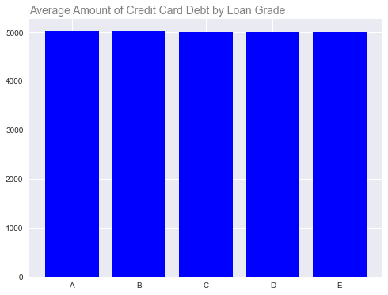

```python
fig, ax = plt.subplots(figsize = (8,6))
ax.bar(loan_df.index, loan_df.Mean, color = 'blue')
ax.set_title('Average Amount of Credit Card Debt by Loan Grade',
             fontdict = {'fontsize' : 14,
                         'color' : 'gray'},
             loc = 'left');
```

### 4. Using the groupBy Parameter

a. You can also add the groupBy parameter on a **CASTable** object to achieve similar results. Here, we specify **LoanGrade** as the groupBy parameter value and add the **Amount** column to the vars parameter. View the **CASTable** object created earlier prior to adding the parameters, then and after. Notice that the where parameter still exists, and the vars and groupBy parameters were added.

```python
display(ccTbl)

ccTbl.groupBy = 'LoanGrade'
ccTbl.vars = ['Amount']
ccTbl
```

```
CASTable('loans_raw', caslib='casuser', where='Category = "Credit Card"')
```

```
CASTable('loans_raw', caslib='casuser', groupby='LoanGrade', vars=['Amount'], where='Category = "Credit Card"')
```

b. Once the groupBy parameter is added to the **CASTable** object, you can execute methods on the **CASTable** object that contains the groupBy, vars, and where parameters. Here, the mean of each value of **LoanGrade** is calculated for all *Credit Card* rows using the mean method. Notice that the groupBy parameter returns a **SASDataFrame** instead of a **Series** as previously shown.

```python
ccTbl.mean()
```

| LoanGrade | Amount |
| --- | --- |
| A | 5022.305018 |
| B | 5021.681641 |
| C | 5002.771208 |
| D | 5008.242830 |
| E | 4995.316878 |

c. You can also execute actions on the **CASTable** object. Here, the summary action is executed to achieve similar results. Remember, executing an action on a group returns a **CASResults** object with a **SASDataFrame** for each unique groupBy value.

To combine all **SASDataFrame** objects in a **CASResults** object, you can use the concat_bygroups method. Then call the *Summary* key to return the **SASDataFrame**.

```python
cr = ccTbl.summary(subSet = ['MEAN'])

loanGrade_df = cr.concat_bygroups()['Summary']
loanGrade_df
```

Descriptive Statistics for LOANS_RAW

| LoanGrade | Column | Mean |
| --- | --- | --- |
| A | Amount | 5022.305018 |
| B | Amount | 5021.681641 |
| C | Amount | 5002.771208 |
| D | Amount | 5008.242830 |
| E | Amount | 4995.316878 |

### 5. Terminate the CAS Session

It's best practice to always terminate the CAS session when you are done.

```python
conn.terminate()
```